# データ分析実習③

更新：2026-07-01

## 実習 1

### データ

**映画のクチコミとオピニオン・リーダーに関する調査データ**（data_wom.csv）

| OPL1 | OPL2 | OPL3 | eOPL1 | eOPL2 | eOPL3 | WOM1 | WOM2 | eWOM1 | eWOM2 | CLM1 | CLM2 |
| --- | --- | --- | --- | --- | --- | --- | --- | --- | --- | --- | --- |
| 4 | 4 | 3 | 4 | 3 | 5 | 2 | 1 | 2 | 2 | 4 | 4 |
| 6 | 7 | 4 | 2 | 1 | 1 | 7 | 7 | 1 | 2 | 2 | 2 |
| 4 | 5 | 5 | 5 | 6 | 6 | 2 | 2 | 7 | 5 | 7 | 7 |
| 3 | 2 | 2 | 2 | 2 | 2 | 3 | 2 | 3 | 3 | 2 | 2 |
| 7 | 3 | 5 | 2 | 2 | 5 | 5 | 4 | 3 | 3 | 2 | 2 |
| 5 | 2 | 3 | 2 | 4 | 3 | 3 | 3 | 4 | 5 | 1 | 1 |

| 変数 | 定義 | 潜在変数 |
| --- | --- | --- |
| OPL1 | 友人や近所の人と映画についてよく話しをする | オピニオン・リーダー度 (OPL) |
| OPL2 | 友人や近所の人に映画の情報を教える方だ | オピニオン・リーダー度 (OPL) |
| OPL3 | 友人や近所の人から映画についての情報を求められる方だ | オピニオン・リーダー度 (OPL) |
| eOPL1 | インターネット上で映画について投稿したり読んだりする方だ | eオピニオン・リーダー度 (eOPL) |
| eOPL2 | インターネット上で映画の情報を教える方だ | eオピニオン・リーダー度 (eOPL) |
| eOPL3 | インターネット上で人から映画についての情報を求められる方だ | eオピニオン・リーダー度 (eOPL) |
| WOM1 | 満足，面白いと思った映画について友人などに伝える | クチコミ発信 (WOM) |
| WOM2 | 不満，面白くないと思った映画について友人などに伝える | クチコミ発信 (WOM) |
| eWOM1 | 満足，面白いと思った映画についてインターネットの掲示板などに書き込む | eクチコミ発信 (eWOM) |
| eWOM2 | 不満，面白くないと思った映画についてインターネットの掲示板などに書き込む | eクチコミ発 信 (eWOM) |
| CLM1 | 不満，面白くないと思った映画について映画，配給元に電話する | 企業への苦情 (CLM) |
| CLM2 | 不満，面白くないと思った映画について映画，配給元にメールする | 企業への苦情 (CLM) |

**データ出典**：里村（2014）および濱岡・里村（2009）を元に作成したシミュレーションデータ

- 回答者数は200人
- それぞれの質問項目は7点尺度（1＝全く当てはまらない ～ 7＝非常に当てはまる）の回答
- 質問項目 OPL1～CLM2 の数値は，里村（2014）に記載された相関係数行列より復元したシミュレーションデータで実際のアンケート回答結果とは異なる

**参考文献**  
[里村卓也 (2014) 『マーケティング・データ分析の基礎』共立出版](http://www.kyoritsu-pub.co.jp/bookdetail/9784320123663)  
[濱岡豊, 里村卓也 (2009) 『消費者間の相互作用についての基礎研究 : クチコミ、eクチコミを中心に』慶應義塾大学出版](http://www.keio-up.co.jp/np/isbn/9784766415971)

### 課題

以下のパス図で共分散構造分析を実行し，リアルとインターネットでのオピニオンリーダー度（OPLとeOPL）は，リアルとインターネットでのクチコミ発信（WOMとeWOM）にどのような影響を与えているか考察せよ。

- 天井・床効果とクロンバックアルファの確認は省略してよい。

#### モデル（パス図）

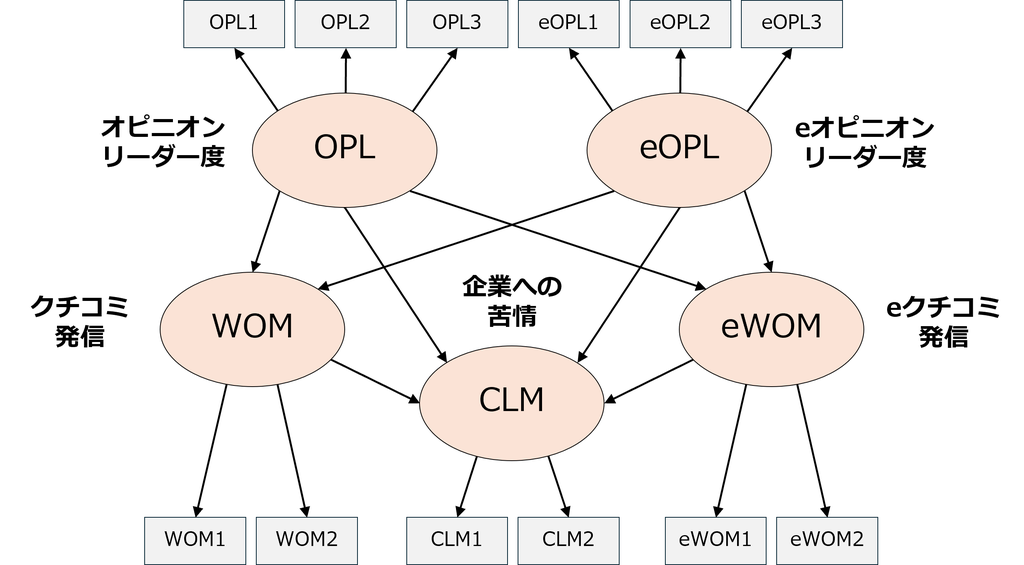

**Rコード（クリックで表示）**

```r
library(psych)
library(lavaan)

# データの読み込み
data_wom <- read.csv("data/data_wom.csv")

# 信頼性係数（クロンバックのアルファ）の確認
summary(alpha(data_wom[, 1:3]))  # OPL
summary(alpha(data_wom[, 4:6]))  # eOPL
summary(alpha(data_wom[, 7:8]))  # WOM
summary(alpha(data_wom[, 9:10]))  # eWOM
summary(alpha(data_wom[, 11:12])) # CLM

# モデル（パス図）定義
model <- "
  # 測定方程式
    OPL =~ OPL1 + OPL2 + OPL3
    eOPL =~ eOPL1 + eOPL2 + eOPL3
    WOM =~ WOM1 + WOM2
    eWOM =~ eWOM1 + eWOM2
    CLM =~ CLM1 + CLM2
  # 構造方程式
    WOM ~ OPL + eOPL
    eWOM ~ OPL + eOPL
    CLM ~ OPL + eOPL + WOM + eWOM
"

# パラメータ推定
result <- sem(model, data = data_wom)

# 推定結果の表示
summary(result, standardized = TRUE)

# モデル比較指標
fitMeasures(result, fit.measures = c("gfi", "rmsea"))

# （参考）semPlot パッケージによる作図プログラム
library(semPlot)
semPaths(result, what = "std", style = "lisrel", reorder = FALSE, optimizeLatRes = TRUE,
         manifests = c("OPL1","OPL2","OPL3","eOPL1","eOPL2","eOPL3","WOM1","WOM2","CLM1","CLM2","eWOM1","eWOM2"),
         latents = c("OPL","eOPL","WOM","CLM","eWOM"))
```

## 実習 2

### データ

**Big Five（個人のパーソナリティ）に関するアンケートデータ** (data_bf.csv)

| E1 | E2 | E3 | E4 | E5 | E6 | E7 | E8 | E9 | E10 | N1 | N2 | N3 | N4 | N5 | N6 | N7 | N8 | N9 | N10 | A1 | A2 | A3 | A4 | A5 | A6 | A7 | A8 | A9 | A10 | … |
| --- | --- | --- | --- | --- | --- | --- | --- | --- | --- | --- | --- | --- | --- | --- | --- | --- | --- | --- | --- | --- | --- | --- | --- | --- | --- | --- | --- | --- | --- | --- |
| 4 | 2 | 5 | 2 | 5 | 1 | 4 | 3 | 5 | 1 | 1 | 5 | 2 | 5 | 1 | 1 | 1 | 1 | 1 | 1 | 1 | 5 | 1 | 5 | 2 | 3 | 1 | 5 | 4 | 5 | … |
| 2 | 2 | 3 | 3 | 3 | 3 | 1 | 5 | 1 | 5 | 2 | 3 | 4 | 2 | 3 | 4 | 3 | 2 | 2 | 4 | 1 | 3 | 3 | 4 | 4 | 4 | 2 | 3 | 4 | 3 | … |
| 5 | 1 | 1 | 4 | 5 | 1 | 1 | 5 | 5 | 1 | 5 | 1 | 5 | 5 | 5 | 5 | 5 | 5 | 5 | 5 | 5 | 1 | 5 | 5 | 1 | 5 | 1 | 5 | 5 | 5 | … |
| 2 | 5 | 2 | 4 | 3 | 4 | 3 | 4 | 4 | 5 | 5 | 4 | 4 | 2 | 4 | 5 | 5 | 5 | 4 | 5 | 2 | 5 | 4 | 4 | 3 | 5 | 3 | 4 | 4 | 3 | … |
| 3 | 1 | 3 | 3 | 3 | 1 | 3 | 1 | 3 | 5 | 3 | 3 | 3 | 4 | 3 | 3 | 3 | 3 | 3 | 4 | 5 | 5 | 3 | 5 | 1 | 5 | 1 | 5 | 5 | 5 | … |
| 1 | 5 | 2 | 4 | 1 | 3 | 2 | 4 | 1 | 5 | 1 | 5 | 4 | 5 | 1 | 4 | 4 | 1 | 5 | 2 | 2 | 2 | 3 | 4 | 3 | 4 | 3 | 5 | 5 | 3 | … |

**データ出典** ：[Open psychology data: Raw data from online personality tests](https://openpsychometrics.org/_rawdata/)

- 上記サイトの “Answers to the Big Five Personality Test, constructed with items from the International Personality Item Pool.” を利用
- 本分析例のため元データの一部を修正・削除した

| 変数名 | 内容 |
| --- | --- |
| E1 ~ E10 | 外向性（Extraversion）に関する質問項目 |
| N1 ~ N10 | 神経症的傾向（Neuroticism）に関する質問項目 |
| A1 ~ A10 | 協調性（Agreeableness）に関する質問項目 |
| C1 ~ C10 | 誠実性（Conscientiousness）に関する質問項目 |
| O1 ~ O10 | 開放性（Openness to experience）に関する質問項目 |
| age | 年齢 |
| gender | 性別（0＝男性，1＝女性） |
| race | 人種（13種類） |

**Big Five**：心理学分野で開発された個人パーソナリティの分類するための5指標

- 外向性：自己主張や社交性の高さ
- 神経症的傾向：心理的ストレスを受けやすさ
- 協調性：思いやりや調和性の高さ
- 誠実性：自己コントロール能力や計画性の高さ
- 開放性：好奇心や想像力の高さ

**各指標の質問項目と人種の詳細（クリックで表示）**

質問文（日本語）は Wikipedia のビッグファイブ（心理学）を参考とした。

**外向性（Extraversion）**

| 変数 | 質問文（英語） | 質問文（日本語） |
| --- | --- | --- |
| E1 | I am the life of the party. | 私は盛り上げ役だ。 |
| E2 | I don’t talk a lot. | 私はあまり喋らない。（逆転） |
| E3 | I feel comfortable around people. | 私は多くの人といるとくつろぐ。 |
| E4 | I keep in the background. | 私は大勢の人がいる中で話すつもりはない。（逆転） |
| E5 | I start conversations. | 私からよく会話を始める。 |
| E6 | I have little to say. | 私は多くを語らない。（逆転） |
| E7 | I talk to a lot of different people at parties. | 私はパーティーではたくさんの色々な人たちと話す。 |
| E8 | I don’t like to draw attention to myself. | 私は周りのみんなから注目されるのが好きではない。（逆転） |
| E9 | I don’t mind being the center of attention. | 私はみんなからの注目の的であることを気にしない。 |
| E10 | I am quiet around strangers. | 私は見知らぬ人が周りにいる時は静かにしている。（逆転） |

**神経症的傾向（Neuroticism）**

| 変数 | 質問文（英語） | 質問文（日本語） |
| --- | --- | --- |
| N1 | I get stressed out easily. | 私はストレスが溜まりやすい。 |
| N2 | I am relaxed most of the time. | 私はほとんどの時間でリラックスしている。（逆転） |
| N3 | I worry about things. | 私は物事を心配しがちだ。 |
| N4 | I seldom feel blue. | 私はブルーな気分になることは滅多にない。（逆転） |
| N5 | I am easily disturbed. | 私は簡単に動揺する。 |
| N6 | I get upset easily. | 私はすぐにイライラする。 |
| N7 | I change my mood a lot. | 私は頻繁に気分が変わる。 |
| N8 | I have frequent mood swings. | 私は気分にムラがあることが多い。 |
| N9 | I get irritated easily. | 私は簡単にイライラする。 |
| N10 | I often feel blue. | 私はよくブルーな気分になる。 |

**協調性（Agreeableness）**

| 変数 | 質問文（英語） | 質問文（日本語） |
| --- | --- | --- |
| A1 | I feel little concern for others. | 私は他の人のことをほとんど心配しません。（逆転） |
| A2 | I am interested in people. | 私は人に興味がある。 |
| A3 | I insult people. | 私は人を侮辱する。（逆転） |
| A4 | I sympathize with others’ feelings. | 私は他人の気持ちに共感する。 |
| A5 | I am not interested in other people’s problems. | 私は他の人が抱えている問題には興味がない。（逆転） |
| A6 | I have a soft heart. | 私には優しい心がある。 |
| A7 | I am not really interested in others. | 私は他人にはあまり興味がない。（逆転） |
| A8 | I take time out for others. | 私は他の人のために時間をかける。 |
| A9 | I feel others’ emotions. | 私は他人の感情を感じることができる。 |
| A10 | I make people feel at ease. | 私は苦労なく人々を安心させられる。 |

**誠実性（Conscientiousness）**

| 変数 | 質問文（英語） | 質問文（日本語） |
| --- | --- | --- |
| C1 | I am always prepared. | 私はいつも準備をする。 |
| C2 | I leave my belongings around. | 私は身の回りのものはほったらかしにする（逆転） |
| C3 | I pay attention to details. | 私は細部に注意を払う。 |
| C4 | I make a mess of things. | 私は物事をぐちゃぐちゃにしてしまう（逆転） |
| C5 | I get chores done right away. | 私はすぐに雑用を済ませる。 |
| C6 | I often forget to put things back in their proper place. | 私は使ったものを元の場所に戻すのをよく忘れる（逆転） |
| C7 | I like order. | 私は秩序を好む。 |
| C8 | I shirk my duties. | 私はやるべきことを怠る（逆転） |
| C9 | I follow a schedule. | 私は計画通りに物事をこなす。 |
| C10 | I am exacting in my work. | 私は仕事に追われている。 |

**開放性（Openness to experience）**

| 変数 | 質問文（英語） | 質問文（日本語） |
| --- | --- | --- |
| O1 | I have a rich vocabulary. | 私は豊かな語彙を持つ。 |
| O2 | I have difficulty understanding abstract ideas. | 私にとって抽象的なアイディアを理解するのは難しい。（逆転） |
| O3 | I have a vivid imagination. | 私は行き来とした想像力を持つ。 |
| O4 | I am not interested in abstract ideas. | 私は抽象的なことには興味がない。（逆転） |
| O5 | I have excellent ideas. | 私には素晴らしいアイディアがある。 |
| O6 | I do not have a good imagination. | 私には豊かな想像力がない。（逆転） |
| O7 | I am quick to understand things. | 私は物事をすぐに理解できる。 |
| O8 | I use difficult words. | 私は難しい言葉を使う。 |
| O9 | I spend time reflecting on things. | 私は物事をじっくり考える。 |
| O10 | I am full of ideas. | 私にはたくさんのアイディアがある。 |

**人種**

| 番号 | 人種 |
| --- | --- |
| 1 | Mixed Race |
| 2 | Arctic (Siberian, Eskimo) |
| 3 | Caucasian (European) |
| 4 | Caucasian (Indian) |
| 5 | Caucasian (Middle East) |
| 6 | Caucasian (North African, Other) |
| 7 | Indigenous Australian |
| 8 | Native American |
| 9 | North East Asian (Mongol, Tibetan, Korean Japanese, etc) |
| 10 | Pacific (Polynesian, Micronesian, etc) |
| 11 | South East Asian (Chinese, Thai, Malay, Filipino, etc) |
| 12 | West African, Bushmen, Ethiopian |
| 13 | Other |

### 課題

1. 探索的因子分析により各回答者のビックファイブ得点（5因子の因子スコア）を計算
2. ビックファイブ得点をクラスター数4の非階層的クラスタリング（K-means）で分析
3. 各セグメントの平均年齢・性別比も含めてクラスタリング結果を解釈

**Rコード（クリックで表示）**

```r
# データの読込
data_bf <- read.csv("data/data_bf.csv")

# 課題1 ----
fa <- factanal(data_bf[,1:50], factors = 5, scores = "regression")

print(fa, cutoff = 0.3) # 因子負荷量, cutoff = 0.3 で絶対値0.3以上の負荷量のみ表示
fa$scores  # 因子スコア

# 課題2 ----
set.seed(1) # 乱数シードの固定
result <- kmeans(x = fa$scores, centers = 4)

result$centers # 各セグメントの因子スコアの平均値（代表値）
result$cluster # 各回答者の所属セグメント番号
result$size/nrow(data_bf) # 各セグメントの所属比率

# 課題3 ----
aggregate(data_bf$age ~ result$cluster, FUN = mean)    # 平均年齢
aggregate(data_bf$gender ~ result$cluster, FUN = mean) # 女性比率

prop.table(table(result$cluster, data_bf$race), 1)     # （参考）人種比率
```

#### クラスター分析以外のRコード

##### 因子分析

```r
# データの読込
data_bf <- read.csv("data/data_bf.csv")

fa <- factanal(data_bf[,1:50], factors = 5, scores = "regression")

print(fa, cutoff = 0.3) # 因子負荷量, cutoff = 0.3 で絶対値0.3以上の負荷量のみ表示
fa$scores  # 因子スコア
```

**`factanal(data, factors, scores)`**：因子分析の実行

- **`data`**：分析データの指定 ⇒ `data_bf[,1:50]` でデータ内の質問項目（1〜50列）のみ指定
- **`factors`**：因子数の指定 ⇒ Big Five尺度の通り5を指定
- **`scores`**：因子スコアの計算方法

因子負荷量

```
##
## Call:
## factanal(x = data_bf[, 1:50], factors = 5, scores = "regression")
##
## Uniquenesses:
##    E1    E2    E3    E4    E5    E6    E7    E8    E9   E10    N1    N2    N3
## 0.542 0.524 0.424 0.486 0.397 0.598 0.416 0.688 0.616 0.537 0.530 0.736 0.596
##    N4    N5    N6    N7    N8    N9   N10    A1    A2    A3    A4    A5    A6
## 0.867 0.680 0.430 0.448 0.402 0.462 0.536 0.807 0.586 0.726 0.368 0.554 0.617
##    A7    A8    A9   A10    C1    C2    C3    C4    C5    C6    C7    C8    C9
## 0.511 0.640 0.464 0.690 0.615 0.689 0.764 0.555 0.588 0.625 0.707 0.696 0.595
##   C10    O1    O2    O3    O4    O5    O6    O7    O8    O9   O10
## 0.724 0.665 0.665 0.693 0.754 0.559 0.725 0.700 0.694 0.810 0.500
##
## Loadings:
##     Factor1 Factor2 Factor3 Factor4 Factor5
## E1   0.670
## E2  -0.678
## E3   0.655
## E4  -0.698
## E5   0.733
## E6  -0.568
## E7   0.738
## E8  -0.552
## E9   0.606
## E10 -0.651
## N1           0.670
## N2          -0.494
## N3           0.597
## N4          -0.319
## N5           0.539
## N6           0.741
## N7           0.723
## N8           0.752
## N9           0.708
## N10          0.611
## A1                  -0.424
## A2   0.347           0.531
## A3                  -0.401
## A4                   0.790
```

[output cut: 20 more lines]

```
## O5                                   0.607
## O6                                  -0.506
## O7                                   0.488
## O8                                   0.535
## O9                                   0.335
## O10                                  0.679
##
##                Factor1 Factor2 Factor3 Factor4 Factor5
## SS loadings      4.995   4.606   3.761   3.275   3.162
## Proportion Var   0.100   0.092   0.075   0.066   0.063
## Cumulative Var   0.100   0.192   0.267   0.333   0.396
##
## Test of the hypothesis that 5 factors are sufficient.
## The chi square statistic is 57376.74 on 985 degrees of freedom.
## The p-value is 0
```

因子スコア（最初の6人分のみ表示）

```
##         Factor1     Factor2     Factor3      Factor4    Factor5
## [1,]  1.0634496 -1.85974354  0.56123253  1.318260800  0.4174127
## [2,] -0.7819427 -0.18998088 -0.19116641  0.951789002 -1.9228742
## [3,]  0.6049793  2.37241881  0.11497870  2.112999961  0.8416754
## [4,] -0.5876145  1.50800553 -0.02408379 -0.803975604  0.6020167
## [5,]  0.2312989 -0.04627606  1.00409523 -0.231164260 -0.9254773
## [6,] -1.4935329 -0.39798760 -0.04720913 -0.005043807 -0.7854546
```

##### クラスター別の集計

```r
# 以下では result を kmeans の出力オブジェクトとする
aggregate(data_bf$age ~ result$cluster, FUN = mean)    # 平均年齢
aggregate(data_bf$gender ~ result$cluster, FUN = mean) # 女性比率
```

**`aggregate(y ~ x, FUN)`**：データサブセットの要約統計量

- **`y`**：要約する変数
- **`x`**：データをサブセットに分割する基準 ⇒ 各回答者の所属セグメント番号
- **`FUN`**：計算する統計量 ⇒ 平均値の場合は `mean`